# Procedimiento para realizar la Clasificación Jerárquica de un corpus de asociaciones verbales

## Preparativos

Para poder gestionar los procedimientos para la generación de la *clasificación jerárquica* de las asociaciones verbales, es necesario facilitar dicho proceso. En este sentido, será indispensable instalar una interface llamada [RStudio](https://www.rstudio.com/products/rstudio/). Con esta aplicación podremos hacer un manejo más accesible de los comandos en **R**.

Los pasos para esto son:

1. Tener instalado previamente ***R*.
2. Descargar de la página de [RStudio](https://www.rstudio.com/products/rstudio/) la versión para nuestro sistema operativo *(Linux, Windows o Mac OSX)*.
3. Se sigue el proceso de instalación para el sistema operatvo que tengamos, que básicamente consiste en hacer clic en “siguiente” hasta el final. En general no hay oopciones especiales que configurar.
1. [Descargar para Windows](https://download1.rstudio.org/desktop/windows/RStudio-1.4.1106.exe)
2. [Descargar para Mac OSX](https://download1.rstudio.org/desktop/macos/RStudio-1.4.1106.dmg)
4. Una vez instalada la interfáz [RStudio](https://www.rstudio.com/products/rstudio/), se abre directamente, y por medio de ésta ya se podrá trabajar en **R**, sin necesidad de abrier la consola. Esto facilitará el trabajo reduciendo el uso de sólo código para los procedimientos requeridos.

## Pasos para la realización de la *clasificación jerárquica*

Los pasos a seguir para la *clasificación jerárquica* de asociaciones verbales en ****R** son:

1. Importar los datos a **R**.
2. Convertir los datos a objeto tipo `data.frame`.
3. Convertir los datos a objeto tipo matriz.
4. Calcular la matriz de distancia.
5. Obtener un objeto tipo *cluster*, mismo que contendrá los datos de la calsificación de los datos y será el insumo para graficar el dendograma correspondiente.
6. Se realiza finalmente por medio de la inspección minuciosa, la interpretación de los datos graficados y realización del informe correspondiente a la descripción detallada de la *representación social*.

A continuación se describe a detalle cada uno de los pasos del **1** al **5**, ya que el **6** ya no requiere el uso del programa porque ya la información ha sido procesada, analizada y resumida en el gráfico.

### 1. Importar los datos a **R**

Los datos necesarios para trabajar los procedimientos de la *clasificación jerárquica*, es en términos simples una tabla de frecuencias ya sea sintetizada en MS Excel, o extraídos directamente de las salidas generadas por IRAMUTEQ. Esto significa que la importación de datos hacia **R** es muy variada; en este caso, el uso de [RStudio](https://www.rstudio.com/products/rstudio/) permitirá hacer todos estos procesos de importación de datos sin necesidad de utilizar código **R**, lo que vuelve más accesile el propio uso de **R**.

Los datos trabajados y generados por el **IRAMUTEQ** son de tipo *texto separados por comas* (que en este caso son datos separados por “;”) y deberán ser enviados a a **R** para la *clasificación jerárquica*. El procedimiento es:

0. En este caso se parte de que se trabajó previamente en IRAMUTEQ, y en dicho entorno, se abrió un corpus de texto y se obtuvieron las estadísticas básicas del texto. La secuencia será una vez que se abra el corpus de texto, ANÁLISIS DE TEXTO > ESTADÍSTICOS.
1. En el panel HISTORIAL del lado izquierdo, se puede identificar en los corpus de texto, los despliegues analíticos realizados y donde quedan los estadísticos puede darse clic derecho y elegir OPEN DIRECTORY o ABRIR DIRECTORIO.

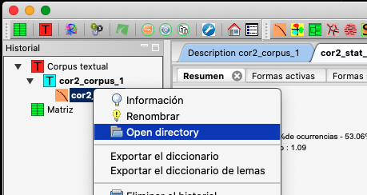

1. Hacer clic en FILE o ARCHIVO (según el idioma en el que se instala el programa Rstudio) > IMPOR o IMPORTAR > FROM TEXT (READR) o DESDE TEXTO (READR).
2. En la ventana de archivos que se abre al hacer clic en el botón

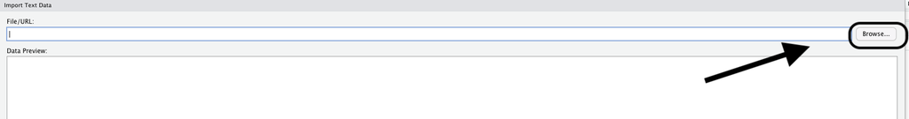

   ,, debe navegarse hasta la carpeta donde se guardaron las estadísticas del corpus textual, ingresar a la carpeta de estadísticos y seleccionar el documento “formes_actives_csv”[^1].
3. Al seleccionar el archivo indicado, se abrirá un cuadro de diálogo con varias opciones. Para hacer la importación se modifica sólo el valor correspondiente al separador de los datos.
1. Localice la opción “Delimiter” en la opción inferior de la pantalla.
2. Se selecciona la opción “;” ó si está en inglés “Semicolon” Se verá cómo los datos en la pantalla se acomodan por columnas.
4. El objeto en el espacio de trabajo de **R** se llamará `formes_actives`. Para verlo, se hace lo siguiente en la consola de **R**:

```r
ls() #Este comando muestra todos los objetos del espacio de trabajo.
```

```
## [1] "formes_actives"
```

Con estas acciones queda lista la importación de datos. Ahora es necesario preparar los datos para el análisis de *clasificación jerárquica*.

### 2. Convertir los datos a objeto tipo `data.frame``

Para la preparación de los datos, lo primero es la conversión de dichos datos a tipo `data.frame`. Hay que indicar que durante todo el procedimiento, las conversiones de objetos de datos es habitual, de modo que esto debe entenderse como parte de las convenciones de **R** para el procesamiento de información.

1. En principio se deben visualizar parcialmente los datos:

```r
head(formes_actives) #este comando permite inspeccionar las primeras filas del conjunto de datos a fin de ver el contenido y estructura que guardan.
```

```
##             X1 X2  X3
## 1 comunicación 29 nom
## 2    expresión 10 nom
## 3  herramienta  7 nom
## 4       hablar  7 ver
## 5  interacción  4 nom
## 6    habilidad  4 nom
```

Obsérvese cómo los encabezados de cada columna se identifican como `X1, X2` Y `X3`. PARA NUESTRO `data.frame` SÓLO TULIZAREMOD `X1` Y `X2`.

Paara convertir estos datos a `data.frame`, hacemos lo siguiente:

```r
fa <- as.data.frame(formes_actives[1:2]) # Vuelve a copiar el objeto que importamos originalmente, pero como un data.frame. La especificación "[1:2] al final del nombre del objeto a convertir, es para indicar que sólo necesitamos las dos primeras columnas."
```

Asó obtenemos:

```r
head(fa) #"fa" es el nombre para el nuevo objeto tipo data frame que se creó en el comando anterior.
```

```
##             X1 X2
## 1 comunicación 29
## 2    expresión 10
## 3  herramienta  7
## 4       hablar  7
## 5  interacción  4
## 6    habilidad  4
```

Y se observa claramente que ya el nuevo objeto sólo tiene las dos columnas que digimos que se utilizarían. Ahora bien, es necesario delimitar el `data.frame` para que éste quede listo para la siguiente conversión a matriz. Para ello, debimos haber tomado nota de la cantidad de términos o asociaciones verbales que queremos clasificar; desde luego, esa depuración debe incluir los *hápax* y demás términos cuyas pocas frecuencias no nos interesen. Para esto, hagamos una inspección completa del `data.frame`, afortunadamente, desde que se están importando, los datos se encuentran ordenados de mayor a menor, lo que facilita estas decisiones. Para facilitar aún más esta inspección, ajustaremos los nombres de las columnas del `data.frame` y luego su despliegue.

```r
names(fa)<-c("palabra","frecuencia")
fa
```

```
##          palabra frecuencia
## 1   comunicación         29
## 2      expresión         10
## 3    herramienta          7
## 4         hablar          7
## 5    interacción          4
## 6      habilidad          4
## 7       expresar          4
## 8      comunicar          4
## 9           oral          3
## 10      escribir          3
## 11    desarrollo          3
## 12   comunicarse          3
## 13   aprendizaje          3
## 14        social          2
```

[output cut: 32 more lines]

En este caso concreto, puede verse que los *hápax* aparecen a partir de la fila `22`, razón por la que decidimos para este caso, sólo excluir los *hápax*, ya que al ser un diccionario de asociaciones corto (46 téerminos), no deseamos reducirlo tanto, en el entendido de que esta *representación social* es dispersa, es decir hay pocas palabras con altas frecuencias y el resto corresponden con primeras y segundas periferias. De este modo, el siguiente comando reducirá la lista a 21 filas, es decir, todos los términos con frecuencia = o > que 2.

```r
fa <- fa[1:21,] #Este comando reescribe el data.frame sólo con los casos requeridos. Si hubiera algún error o problema, siembre se cuenta con los datos originales importados para recuperar la lista de frecuencias completa.
```

Lo que resulta en:

```
##         palabra frecuencia
## 1  comunicación         29
## 2     expresión         10
## 3   herramienta          7
## 4        hablar          7
## 5   interacción          4
## 6     habilidad          4
## 7      expresar          4
## 8     comunicar          4
## 9          oral          3
## 10     escribir          3
## 11   desarrollo          3
## 12  comunicarse          3
## 13  aprendizaje          3
## 14       social          2
## 15        señal          2
## 16      persona          2
## 17        mente          2
## 18 inteligencia          2
## 19   expresarse          2
## 20     escuchar          2
## 21     atención          2
```

Con estas acciones tenemos listo el conjunto de datos para continuar con el procedimiento.

### 3. Convertir los datos a objeto tipo matriz.

Lo que sigue es convertir el `data.frame` denominado `fa` en una matriz. Para esto, la variable `palabra`se utilizará como *nombres de fila* y la variable `frecuencia` como una dimensión de la matriz. Para hacer esto:

```r
mfa<-as.matrix(fa$frecuencia)
rownames(mfa)<-fa$palabra
```

Obteniendo una matriz con 21 filas en una dimensión, y debidamente identificada en cada una de sus filas con las asocioaciones verbales.

```
##              [,1]
## comunicación   29
## expresión      10
## herramienta     7
## hablar          7
## interacción     4
## habilidad       4
## expresar        4
## comunicar       4
## oral            3
## escribir        3
## desarrollo      3
## comunicarse     3
## aprendizaje     3
## social          2
## señal           2
## persona         2
## mente           2
## inteligencia    2
## expresarse      2
## escuchar        2
## atención        2
```

Ahora es indispensable *estandarizar* la matriz a fin de evitar errores en los cálculos de l algoritmo de clasificación. Para ello:

```r
mfa <- scale(mfa) # El comando `scale()` *estandariza* los datos.
```

Hecho esto, los datos quedan listos para calcular la matriz de distancia y el correspondiente dendograma jerarquizador.

### 4. Calcular la matriz de distancia.

Este paso es sencillo, sólo se corre el siguiente comando para crear un objetotipo *matríz de distancia*. El comando es `dist(`, y el elemento a destacar es que se elige el método euclidiano para su cálculo. Así:

```r
dmfa <- dist(mfa, method="euclidian")
```

Si no es marcado ningún error, entonces quiere decir que va todo bien. Ahora toca crear un objeto tipo *cluster*, mismo que es un objeto que guardará toda la información necesaria para los agrupamientos.

### 5. Crearción del objeto tipo *cluster* y su graficación.

Antes de continuar con este íltimo paso, es necesario contar con dos librerías que si no están instalados, no será posible continuar. en el siguiente comando se llama a estos paquetes:

```r
library("cluster")
library("ape")
```

Si alguno de los paquetes no se encuentra instalado, la consola enviará un mensaje de error, para lo que será necesario instalar los paquetes. Para dicha instalación, se recurre al menú HERRAMIENTAS o TOOLS en los menús de [RStudio](https://www.rstudio.com/products/rstudio/). Una vez ahí debe elegirse la opción INSTALL PACKAGES o INSTALAR PAQUETES, lo que abrirá un cuadro de diálogo para indicar qué paquetes deben instalar.

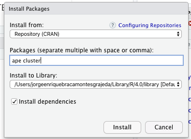

**NOTA IMPORTANTE** Debe cuidarse que esté seleccionada la opción REPSOTORY CRAN antes de hacer clic en INSTALL. UNA VEZ INSTALADO TODO LO NECESARIO, SE PROCEDE A VOLVER A LLAMAR AL PAQUETE QUE MARCÓ ERROR. POR EJEMPLO SI LA LIBRERÍA `APE` MARCÓ ERROR, SE VUELVE A ESCRIBIR `library("ape)` EN LA CONSOLA Y SE OPRINME ENTER, YA NO DEBERÍA MARCAR ERROR.

#### a. Obtención del objeto tipo*cluster*

Así:

```r
# El objeto tipo matríz de distancia se convierte en objeto tipo *cluster* mediante:
cmfa<-hclust(dmfa,method="ward.D")
# El tipo de método sugerido para este tipo de agrupamiento es *ward.D*.
```

#### b. Graficación del dendograma

Obtenido el objeto *cluster*, podemos graficar el dendograma. Los comandos para ello sobn:

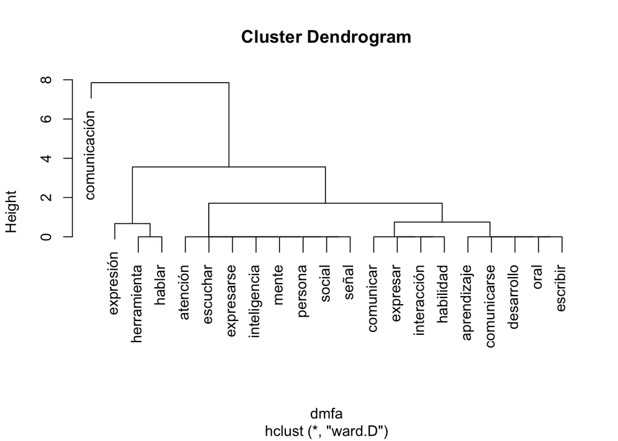

```r
plot(cmfa)
```

Estos resultados pueden mejorarse, por ejemplo, agregando un título al gráfico, adicionando al comando anterior:

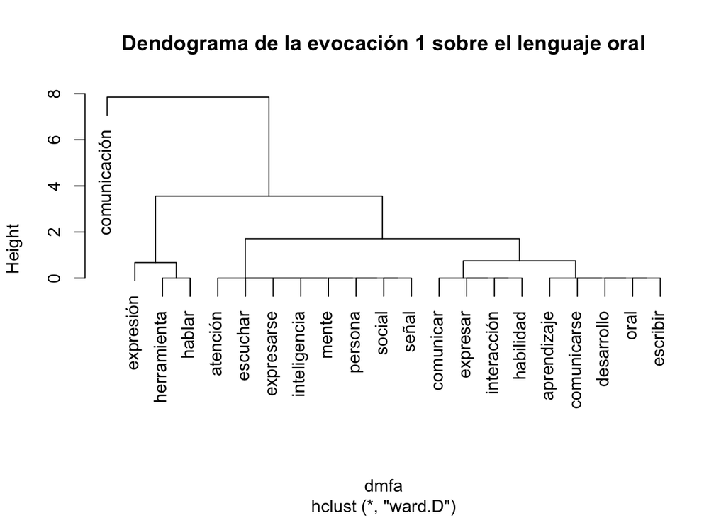

```r
plot(cmfa, main="Dendograma de la evocación 1 sobre el lenguaje oral")
```

Otros resultados estéticos podrían lograrse, ya sea poniendo el dendograma de forma horizontal, o de manera circular. Se elige el que mejor ayuda a comprender los grupos o clusters que se han formado.

**En horizontal:**

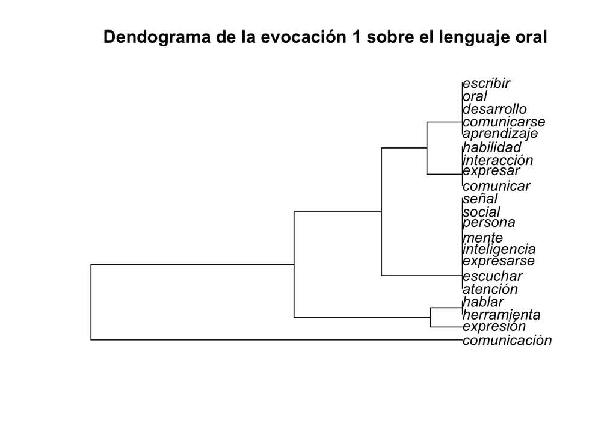

```r
plot(as.phylo(cmfa), main="Dendograma de la evocación 1 sobre el lenguaje oral", horiz=T)
```

**En circular como radio:**

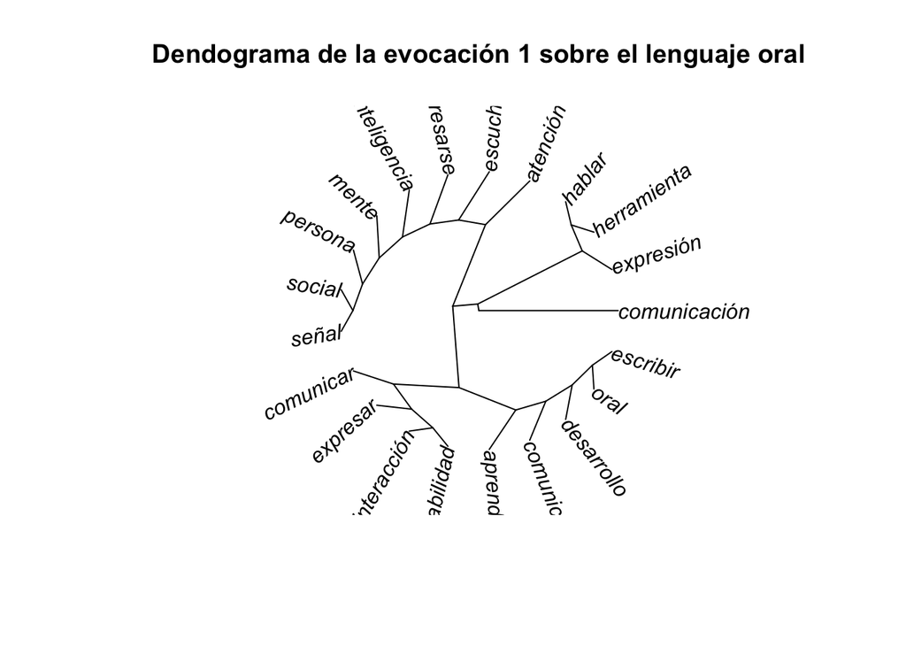

```r
plot(as.phylo(cmfa),type="radial", main="Dendograma de la evocación 1 sobre el lenguaje oral")
```

**En circular como abanico:**

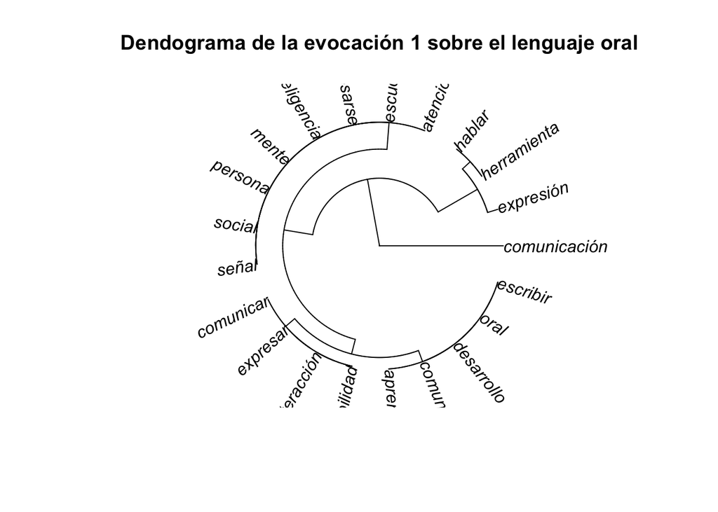

```r
plot(as.phylo(cmfa),type="fan", main="Dendograma de la evocación 1 sobre el lenguaje oral")
```

**En formas triangulares:**

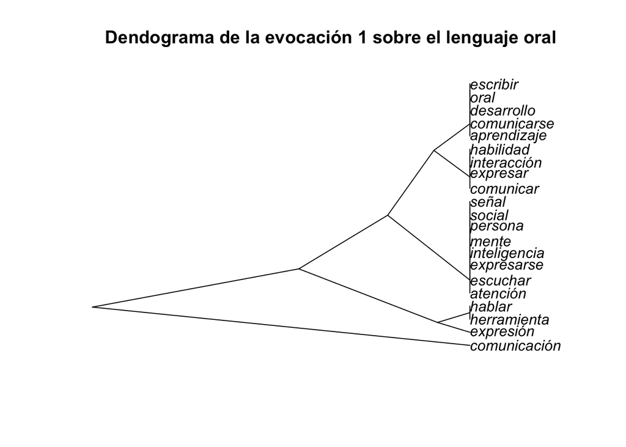

```r
plot(as.phylo(cmfa),type="cladogram", main="Dendograma de la evocación 1 sobre el lenguaje oral")
```

**Des-enraizado:**

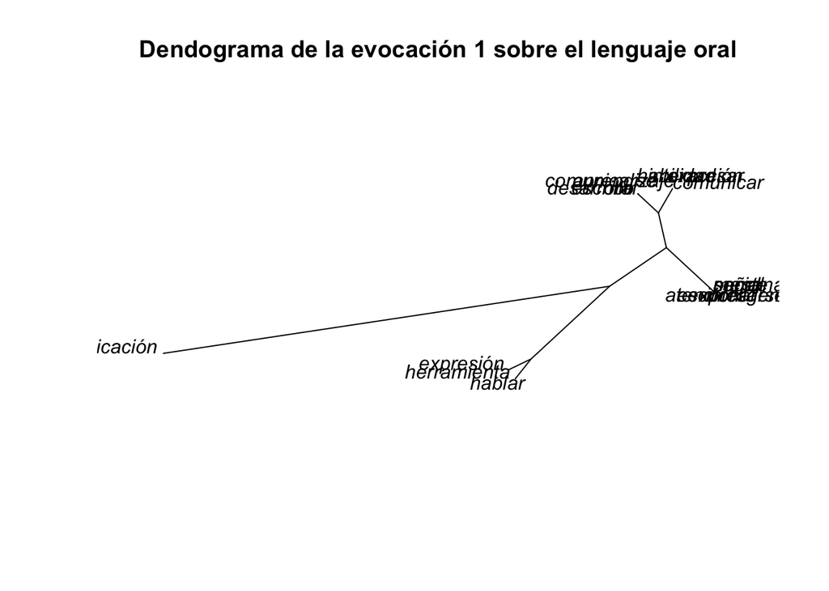

```r
plot(as.phylo(cmfa),type="unrooted", main="Dendograma de la evocación 1 sobre el lenguaje oral")
```

[^1]: Este archivo se genera al abrir un corpus de texto en IRAMUTEQ y correr el análisis de estadísticos básicos.